# EPI 569 – Exercise 4: Multi Strain Dynamics

Author

Victoria Ngo

Published

November 10, 2023

Modified

October 31, 2024

# Background 1

In this exercise, we are going to use a multi-strain model to examine under what conditions a new strain/variant can **emerge**, **persist**, and, perhaps, **replace** existing strains/variants.

Note that we are going to use a **difference equation** model. The main reason for this is that a differential equation model in R can be very sensitive to non-linearities created when a new strain enters the population in the middle of the integration (i.e. model run). In order to avoid this problem, we’ll use difference equations in R. You can also play around with the multi-strain model from [Dynamical Systems Approach to Infectious Disease Epidemiology](https://cran.r-project.org/web/packages/DSAIDE/DSAIDE.pdf), which this exercise is partly based on.

This model tracks susceptible people, people infected with either strain 1 or strain 2, and individuals recovered from infection with strain 1, strain 2 or both. As in previous exercises, infected people are assumed to be infectious. Let’s say that **strain 1 is SARS-CoV-2 Omicron BA.1** and **strain 2 is Omicron BA.5**.

The following compartments are included:

- $S$: uninfected and susceptible individuals
- $I_1$: indviduals who are infected with strain 1
- $I_2$: individuals who are infected with strain 2
- $S_1$: individuals recovered from infection with strain 1, still susceptible to strain 2
- $S_2$: individuals recovered from infection with strain 2, still susceptible to strain 1
- $J_1$: individuals previously infected with strain 2 and now infected with strain 1
- $J_2$: individuals previously infected with strain 1 and now infected with strain 2
- $S_{1,2}$: individuals recovered from infection with both strains 1 and 2.

The included processes/mechanisms are the following:

1. *Susceptible* individuals can become *infected* with either strain 1 or 2.
2. People *infected* with strain 1 or 2 can become *infected* with the other strain.
3. People *infected* with strain 1 or 2 infect *susceptibles* or people *previously infected* with the other strain at rates $\beta_1/\beta_2$. For simplicity, we assume that the rates are independent of the status of the host that becomes infected (e.g. an $S$ host and an $S_1$ can become infected at the same rates with strain 2). It also does not matter if a host has previously recovered from an infection with the other strain.
4. *Infected* people *recover* at the same rates and the rate of recovery does not depend on previous infections.
5. *Recovered* individuals are *immune* to reinfection by the strain they have already been infected with but can still be *infected* with the strain they have not yet been infected with.

The tasks below are described in a way that assumes everything is in units of DAYS (rate parameters, therefore, have units of inverse days). If any quantity is not given in those units, you need to convert it first (e.g. if it says a week, you need to convert it to 7 days).

# Background 2

First, make sure each strain can produce an outbreak by itself by running the model below:

**STEP 2:** Set the contact rate (`alpha`) to 5, both transmission rates (`beta.1` and `beta.2`) to 0.1, and recovery rate (`sigma`) to 0.2 (i.e. 5 day duration of illness). Turn off the deaths/birth rate (`mu`) and the loss of immunity (`omega`) by setting them to 0.

**STEP 3:** Set the cross-immunity parameter (`tau`) to 0.

**STEP 4:** Run the model for 100 days and check that you only get a single outbreak with strain 1.

**STEP 5:** Make sure that strain 2 does not enter the population by setting the time that it appears (`strain.2.day`) *after* the simulation is over (e.g., set to 999).

**STEP 6:** Examine the resultant data frame (`df` in your environment) to see how different compartments change over time.

The code below runs the difference equations model, calculates the total number of cases for each strain, calculates $R_0$ for each strain, and produces two figures; one plotting the incidence over time ($I_1$, $I_2$, $J_1$, and $J_2$), and the other plotting the susceptible and recovered compartments over time ($S$, $S_1$, $S_2$, and $S_{1,2}$).

```r
# Model parameters
alpha <- 5 # per day
mu <- 0 # per day
sigma <- 0.2 # per day
omega <- 0 # per day
tau <- 0
beta.1 <- 0.1
beta.2 <- 0.1

strain.2.day <- 999

S.init <- 99
I.1.init <- 1
I.2.init <- 0
S.1.init <- 1
S.2.init <- 0
J.1.init <- 0
J.2.init <- 0
S.1.2.init <- 0

time.step <- 1
n.steps <- 100

S <- S.init
I.1 <- I.1.init
I.2 <- ifelse(strain.2.day == 0, 1, 0)
S.1 <- 0
S.2 <- 0
J.1 <- 0
J.2 <- 0
S.1.2 <- 0
N <- S + I.1 + I.2 + S.1 + S.2 + J.1 + J.2 + S.1.2

# Difference-equation model
for (t in 1:(n.steps-1)) {
  S[t+1] <- S[t] + (mu * N) - (alpha * (beta.1 * (I.1[t] + J.1[t]) + beta.2 * (I.2[t] + J.2[t]))) * S[t] / N - S[t] * mu
  I.1[t+1] <- I.1[t] + alpha * beta.1 * (I.1[t] + J.1[t]) * S[t] / N - (sigma + mu) * I.1[t]
  I.2[t+1] <- I.2[t] + alpha * beta.2 * (I.2[t] + J.2[t]) * S[t] / N - (sigma + mu) * I.2[t] + ifelse(t == strain.2.day, 1, 0)
  S.1[t+1] <- S.1[t] + sigma * I.1[t] - alpha * beta.2 * (I.2[t] + J.2[t]) * (1 - tau) * S.1[t] / N - mu * S.1[t]
  S.2[t+1] <- S.2[t] + sigma * I.2[t] - alpha * beta.1 * (I.1[t] + J.1[t]) * (1 - tau) * S.2[t] / N - mu * S.2[t]
  J.1[t+1] <- J.1[t] + alpha * beta.1 * (I.1[t] + J.1[t]) * (1 - tau) * S.2[t] / N - (sigma + mu) * J.1[t]
  J.2[t+1] <- J.2[t] + alpha * beta.2 * (I.2[t] + J.2[t]) * (1 - tau) * S.1[t] / N - (sigma + mu) * J.2[t]
  S.1.2[t+1] <- S.1.2[t] + sigma * (J.1[t] + J.2[t]) - mu * S.1.2[t]
}

# Model outputs
df <- data.frame(day = c(1:100), S, I.1, I.2, S.1, S.2, J.1, J.2, S.1.2, N)

total.cases.strain.1 <- as.integer((sum(df$I.1) + sum(df$J.1)) * sigma)
total.cases.strain.1
```

```
[1] 90
```

```r
total.cases.strain.2 <- as.integer((sum(df$I.2) + sum(df$J.2)) * sigma)
total.cases.strain.2
```

```
[1] 0
```

```r
R0.strain.1 <- alpha/sigma*beta.1
R0.strain.1
```

```
[1] 2.5
```

```r
R0.strain.2 <- alpha/sigma*beta.2
R0.strain.2
```

```
[1] 2.5
```

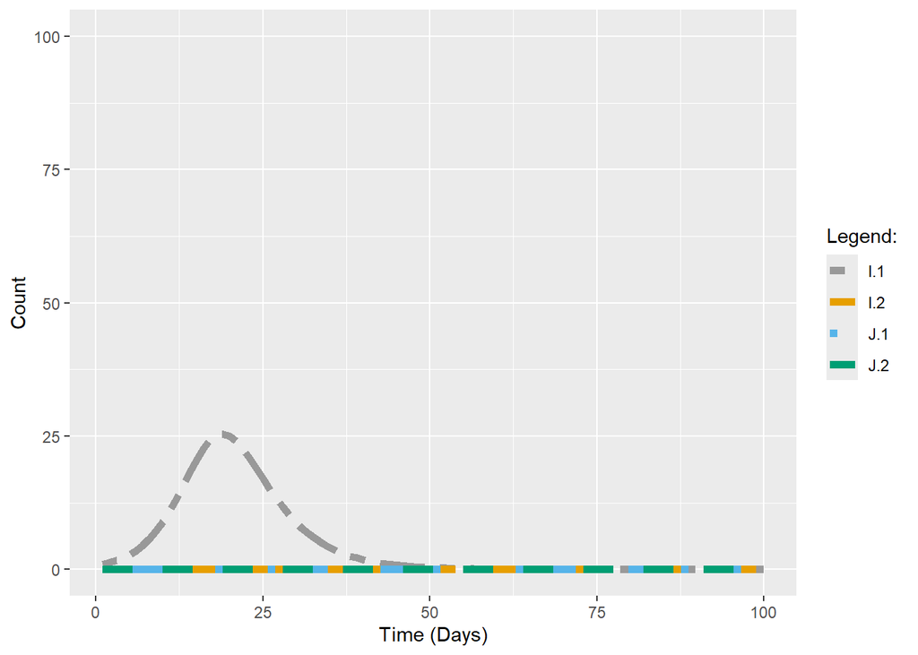

```r
plot1 <- ggplot(data=df, aes(x=day, y=I.1)) +
  geom_line(aes(y=I.1, color="I.1", linetype="I.1"), size=2) +
  geom_line(aes(y=I.2, color="I.2", linetype="I.2"), size=2) +
  geom_line(aes(y=J.1, color="J.1", linetype="J.1"), size=2) +
  geom_line(aes(y=J.2, color="J.2", linetype="J.2"), size=2) +
  scale_linetype_manual(name="Legend:", values=c("I.1"="twodash","I.2"="longdash","J.1"="dotdash","J.2"="dashed")) +
  scale_color_manual(name="Legend:", values=c("I.1"="#999999","I.2"="#E69F00","J.1"="#56B4E9","J.2"="#009E73")) +
  xlab("Time (Days)") + ylim(0,100) + ylab("Count")
plot1
```

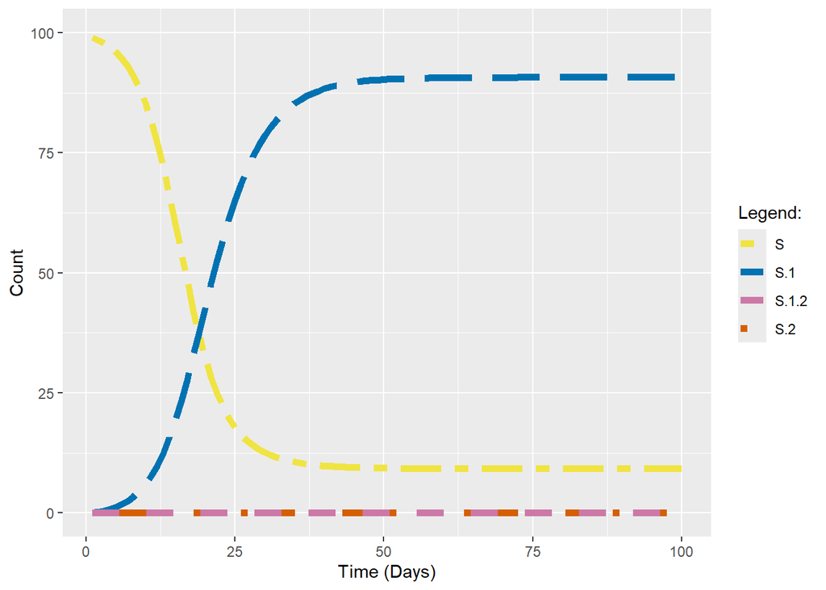

```r
plot2 <- ggplot(data=df, aes(x=day, y=S)) +
  geom_line(aes(y=S, color="S", linetype="S"), size=2) +
  geom_line(aes(y=S.1, color="S.1", linetype="S.1"), size=2) +
  geom_line(aes(y=S.2, color="S.2", linetype="S.2"), size=2) +
  geom_line(aes(y=S.1.2, color="S.1.2", linetype="S.1.2"), size=2) +
  scale_linetype_manual(name="Legend:", values=c("S"="twodash","S.1"="longdash","S.2"="dotdash","S.1.2"="dashed")) +
  scale_color_manual(name="Legend:", values=c("S"="#F0E442","S.1"="#0072B2","S.2"="#D55E00","S.1.2"="#CC79A7")) +
  xlab("Time (Days)") + ylim(0,100) + ylab("Count")
plot2
```

## Question 1 **[2pts]**

1. Why do you get the same or similar dynamics for both model runs (`strain.2.day` = 999 and `strain.2.day` = 0)? *Hint: Remember that* $I_1$ *and* $J_1$ *both represent people infected with strain 1.* $I_2$ *and* $J_2$ *represent people infected with strain 2.* [1 pt]

**ANSWER BELOW**

We get similar dynamics because the other parameters in the model are being held constant.

2. What does it mean when we set `tau` to 0? [1 pt]

**ANSWER BELOW**

When `tau` = 0, there is no cross immunity between the strains. By getting infected by one strain, you are not immune to getting infected by another strain.

## Question 2 **[2pt]**

Keep the initial number infected with strain 1 set to 1 and keep strain 2 appearing on day 0. Now, add in cross-protection by changing the cross-immunity parameter (`tau`) to 0.5. Don’t run your model yet!

1. What do you expect to see? [1 pt]

**ANSWER BELOW**

I expect that S.1.2. should be about equal with S.1. and S.2. at the end of the 100 days.

2. Now run your model R code. What do you find? [1 pt]

**ANSWER BELOW**

My prediction was correct: The number of people in S.1.2. is roughly the same amount as the people in S.1. and S.2. by the end of 100 days. J.1. and J.2. peak around the same time at 26 days. I.1. and I.2. also peak at the same time at day 16 with the same number of cases.

## Question 3 **[2pts]**

Now, change when strain 2 appears to day 50. Keep all other cells the same as in Question 2. Don’t run your model yet!

1. What do you expect to see? [1 pt]

**ANSWER BELOW**

I expect that I.2. and J.2. should have a slight increase after 50 days. Additionally, I.1. should peak early in the 100 day time-frame

2. Now run your model. What did you find? [1 pt]

**ANSWER BELOW**

I.2. and J.2. increases after day 50, with J.2. outpacing I.2.. I.1. also follows my prediction by peaking early with 25 cases.

Overall, S.1. showed a decline after 50 days while S.2. and S.1.2. showed an increase after 50 days. This can be attributed to not having complete cross immunity so people are getting infected by both strains. The previously mentioned J.2. increase can be attributed to there being more people in S.1. than in S.

**Note**

To answer the question above, set `tau` = 0.5, but your are encouraged to play around with it by setting it equal to 0 and 1.

## Question 4 **[2pt]**

Now, increase the transmissibility of strain 2 by setting `beta.2` to 0.2 (keeping all other parameters the same as in Question 3). Don’t run the model yet!

1. What do you expect to see? [0.8 pt]

**ANSWER BELOW**

I expect that I.2. and J.2. will be larger when `beta.2` = 0.2 than when `beta.2` = 0.1. This is because the new strain has a higher transmissibility.

2. What do you find? [0.8 pt]

**ANSWER BELOW**

My prediction was correct: I.2. and J.2. were larger with J.2. having more cases than I.2.. Both peak around day 65.

3. Which has the greater impact: the timing of strain 2’s introduction or strain 2’s higher transmissibility? [0.4 pt]

**ANSWER BELOW**

Strain 2’s higher transmissibility has a bigger impact.

## Question 5 **[2pts]**

Now play around with the cross-immunity parameter (`tau`), which represents the degree of protection that previous infection with one strain has on susceptibility to the other. Record the values that you are using to test this parameter and report them in your answers.

1. Before running your model, what do you expect when you increase/decrease `tau`? [0.8 pts]

**ANSWER BELOW**

I expect that S.1.2. will get lower toward the end of the 100 day period as `tau` is increased. The J.2. curve on the graph should also get lower. Both of these would be attributed to having a higher cross immunity with less people getting infected.

2. After running your model, what did you find? [0.8 pts]

**ANSWER BELOW**

Tau was ran at 0, 0.25, 0.5, and 0.75. As tau increased, J.2. and I.2. peaked at continuously smaller values. Additionally, S.1.2. also decreased as tau increased due to having fewer people infected with both strains.

3. What are you assuming about cross-immunity? [0.2 pts]

**ANSWER BELOW**

We can assume that cross-immunity is the same for the infection of either strain 1 or strain 2.

4. Which has the greater impact: strain 2’s higher transmissibility or the degree of cross-immunity (i.e. the level of immune escape)? [0.2 pts]

**ANSWER BELOW**

Strain 2’s higher transmissibility has a bigger impact.

## Optional exploration **[ungraded]**

Keep exploring. Investigate how some of the other parameters influence the outbreak and endemic dynamics for the two strains. Always follow the same pattern: Think about what results you expect to get from a certain scenario/parameter setting and why. Then check with the simulation. If things don’t agree, figure out why not.

Is there a situation in which a less transmissible strain can emerge?

**ANSWER BELOW**

## Question 6 (Extra Credit) **[1pt]**

Now, let’s use what you’ve observed here to think about what might have happened in Southern Africa with the original Omicron variant.

1. Some have suggested that nearly everyone in the region had been previously infected with SARS-CoV-2. If that’s true, how could Omicron still emerge? [0.33 pts]

**ANSWER BELOW**

2. If Omicron replaced Delta, is it necessarily a more infectious virus? [0.33 pts]

**ANSWER BELOW**

3. At that stage of the pandemic (one variant emerging during an existing epidemic), are you more concerned about an immune escape variant or a more transmissible one? Would you have a different answer at an earlier stage in the epidemic? [0.33 pts]

**ANSWER BELOW**